# Week 4 Tidymodels & GLM

# 1 Tidymodels

Last week we looked at broom (tidy, glance, augment), rsample (splitting data), parsnip (specifying models), and yardstick (evaluating models). For a brief review look at the solution to coding warmup 3 part 4.

Some more helpful tools.

Checking model specification

```
## Random Forest Model Specification (regression)
##
## Computational engine: ranger
##
## Model fit template:
## ranger::ranger(x = missing_arg(), y = missing_arg(), case.weights = missing_arg(),
##     num.threads = 1, verbose = FALSE, seed = sample.int(10^5,
##         1))
```

```
## Random Forest Model Specification (regression)
##
## Main Arguments:
##   trees = 1000
##   min_n = 5
##
## Engine-Specific Arguments:
##   verbose = TRUE
##
## Computational engine: ranger
##
## Model fit template:
## ranger::ranger(x = missing_arg(), y = missing_arg(), case.weights = missing_arg(),
##     num.trees = 1000, min.node.size = min_rows(~5, x), verbose = TRUE,
##     num.threads = 1, seed = sample.int(10^5, 1))
```

As an aside, what is a random forest? It is an ensemble model (meaning it aggregates information from multiple models) which uses numerous decision trees to make predictions (many trees make a forest). In a classification case, usually the prediction is the class selected by the most trees. In the regression case, the average prediction from individual trees is returned.

# 2 GLM

Let’s run a very basic example on [Lending Club data](https://probably.tidymodels.org/articles/where-to-use.html).

```
## Rows: 9,857
## Columns: 23
## $ funded_amnt                <int> 16100, 32000, 10000, 16800, 3500, 10000, 11~
## $ term                       <fct> term_36, term_60, term_36, term_60, term_36~
## $ int_rate                   <dbl> 13.99, 11.99, 16.29, 13.67, 7.39, 11.47, 5.~
## $ sub_grade                  <fct> C4, C1, D1, C3, A4, B5, A1, B2, B3, C2, C3,~
## $ addr_state                 <fct> CT, MN, OH, NV, CA, TX, KY, MO, NY, GA, NH,~
## $ verification_status        <fct> Not_Verified, Verified, Source_Verified, Ve~
## $ annual_inc                 <dbl> 35000, 72000, 72000, 101000, 50100, 32000, ~
## $ emp_length                 <fct> emp_5, emp_ge_10, emp_ge_10, emp_lt_1, emp_~
## $ delinq_2yrs                <int> 0, 0, 0, 0, 0, 0, 0, 2, 0, 1, 0, 0, 0, 1, 0~
## $ inq_last_6mths             <int> 0, 0, 2, 0, 0, 0, 0, 0, 2, 0, 3, 3, 0, 0, 1~
## $ revol_util                 <dbl> 67.4, 82.2, 74.2, 64.0, 78.3, 68.1, 54.8, 3~
## $ acc_now_delinq             <int> 0, 0, 0, 0, 0, 0, 0, 0, 0, 0, 0, 0, 0, 0, 0~
## $ open_il_6m                 <int> 1, 5, 3, 6, 0, 1, 2, 8, 1, 0, 3, 1, 2, 1, 2~
## $ open_il_12m                <int> 0, 1, 2, 1, 0, 0, 0, 2, 0, 0, 1, 2, 1, 0, 4~
## $ open_il_24m                <int> 0, 3, 3, 2, 0, 0, 0, 5, 0, 0, 1, 5, 1, 0, 6~
## $ total_bal_il               <int> 1099, 49187, 33378, 55445, 0, 7574, 20998, ~
## $ all_util                   <int> 48, 77, 79, 64, 78, 66, 54, 80, 75, 36, 43,~
## $ inq_fi                     <int> 0, 0, 1, 1, 0, 0, 0, 0, 2, 1, 1, 1, 0, 1, 7~
## $ inq_last_12m               <int> 3, 0, 4, 4, 0, 0, 0, 4, 6, 1, 3, 5, 1, 0, 5~
## $ delinq_amnt                <int> 0, 0, 0, 0, 0, 0, 0, 0, 0, 0, 0, 0, 0, 0, 0~
## $ num_il_tl                  <int> 3, 9, 9, 10, 3, 9, 7, 21, 7, 1, 7, 19, 7, 6~
## $ total_il_high_credit_limit <int> 13193, 65945, 39387, 60188, 0, 12131, 39486~
## $ Class                      <fct> good, good, good, good, good, good, good, g~
```

Each row is a loan which is either Classified as good or bad.

| engine | mode |
| --- | --- |
| glm | classification |
| glmnet | classification |
| LiblineaR | classification |
| spark | classification |
| keras | classification |
| stan | classification |

| Class | n |
| --- | --- |
| good | 7017 |
| bad | 375 |

We can see that there is a really large class imbalance. Most loans are good. This is something to watch out for! If our model ‘predicts’ every situation as good it will perform deceptively well.

| term | estimate | std.error | statistic | p.value |
| --- | --- | --- | --- | --- |
| (Intercept) | -6.222303e+00 | 1.008831e+00 | -6.167833580 | 6.923195e-10 |
| annual_inc | 6.815608e-07 | 1.128917e-06 | 0.603729866 | 5.460233e-01 |
| verification_statusSource_Verified | -8.226034e-02 | 1.434819e-01 | -0.573315305 | 5.664312e-01 |
| verification_statusVerified | 9.336354e-02 | 1.453496e-01 | 0.642337696 | 5.206539e-01 |
| sub_gradeA2 | 8.502288e-01 | 1.416903e+00 | 0.600061387 | 5.484653e-01 |
| sub_gradeA3 | 2.209308e+00 | 1.121386e+00 | 1.970157270 | 4.882035e-02 |
| sub_gradeA4 | -1.139166e+01 | 2.607569e+02 | -0.043686889 | 9.651540e-01 |
| sub_gradeA5 | 2.108716e+00 | 1.083092e+00 | 1.946940649 | 5.154185e-02 |
| sub_gradeB1 | 2.231726e+00 | 1.063231e+00 | 2.099004693 | 3.581649e-02 |
| sub_gradeB2 | 1.733734e+00 | 1.098047e+00 | 1.578924780 | 1.143533e-01 |

[output cut: 28 more lines]

```
##                         GVIF Df GVIF^(1/(2*Df))
## annual_inc          1.023620  1        1.011741
## verification_status 1.099545  2        1.024008
## sub_grade           1.118988 34        1.001655
```

Multicollinearity is a big issue. If variables are correlated to both the target variable(s) and themselves, the model will not be able to distuingish between their influence. Variance Inflation Factors, (vif 1, orthogonal/uncorrelated, >5 issue).

| Class | .pred_class | .pred_good | .pred_bad |
| --- | --- | --- | --- |
| good | good | 0.9620913 | 3.790871e-02 |
| good | good | 0.9528543 | 4.714565e-02 |
| good | good | 0.9979297 | 2.070275e-03 |
| good | good | 0.9873883 | 1.261173e-02 |
| bad | good | 0.9195388 | 8.046119e-02 |
| good | good | 0.9885870 | 1.141296e-02 |
| good | good | 0.9585885 | 4.141155e-02 |
| good | good | 0.9196687 | 8.033126e-02 |
| good | good | 0.9695693 | 3.043068e-02 |
| good | good | 0.9155059 | 8.449408e-02 |

[output cut: 2455 more lines]

We can predict a class metric or a class probability metric (recall from yardstick).

| Class | .pred_class | n |
| --- | --- | --- |
| good | good | 2322 |
| good | bad | 1 |
| bad | good | 142 |

| Class | mean(.pred_good) | median(.pred_good) |
| --- | --- | --- |
| good | 0.9513516 | 0.9627323 |
| bad | 0.9162079 | 0.9171861 |

| .metric | .estimator | .estimate |
| --- | --- | --- |
| roc_auc | binary | 0.7125772 |

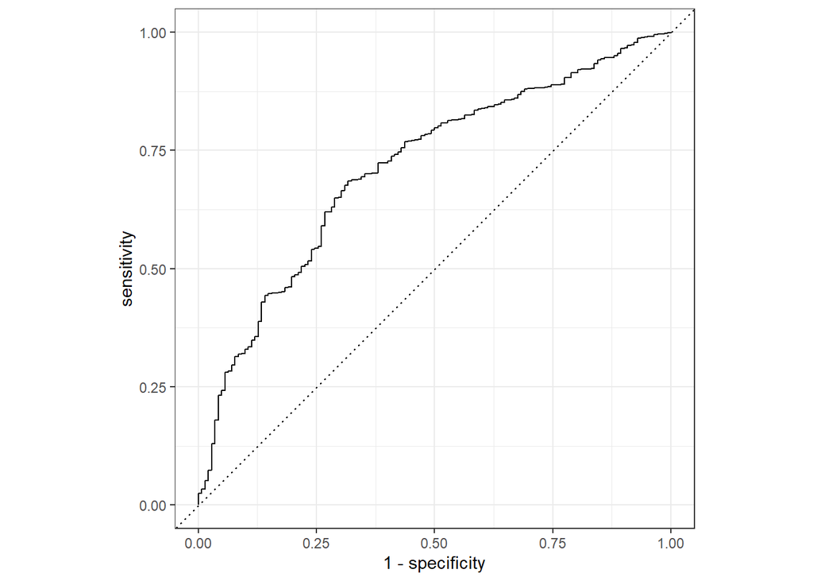

| .metric | .estimator | .estimate |
| --- | --- | --- |
| specificity | binary | 0 |

| .metric | .estimator | .estimate |
| --- | --- | --- |
| sensitivity | binary | 0.9995695 |

The `probably` package lets us find the threshold which maximizes sensitivity (true positives) and specificity (true negatives).

[figure not shown]

| .metric | .estimator | .estimate |
| --- | --- | --- |
| f_meas | binary | 0.9701274 |

| .metric | .estimator | .estimate |
| --- | --- | --- |
| precision | binary | 0.9423701 |

| .metric | .estimator | .estimate |
| --- | --- | --- |
| recall | binary | 0.9995695 |

# 3 Regularlized Regression

| term | estimate | penalty |
| --- | --- | --- |
| (Intercept) | -2.929165 | 0.1 |

| term | estimate | penalty |
| --- | --- | --- |
| (Intercept) | -3.00781528 | 0.01 |
| verification_statusVerified | 0.15005706 | 0.01 |
| sub_gradeD3 | 0.05111726 | 0.01 |
| sub_gradeE1 | 0.56579107 | 0.01 |
| sub_gradeE3 | 0.15453293 | 0.01 |
| sub_gradeF1 | 0.37780540 | 0.01 |
| sub_gradeF2 | 0.55221268 | 0.01 |
| sub_gradeF3 | 0.03215065 | 0.01 |
| sub_gradeF4 | 0.63509189 | 0.01 |
| sub_gradeG2 | 0.09058103 | 0.01 |

[output cut: 1 more lines]

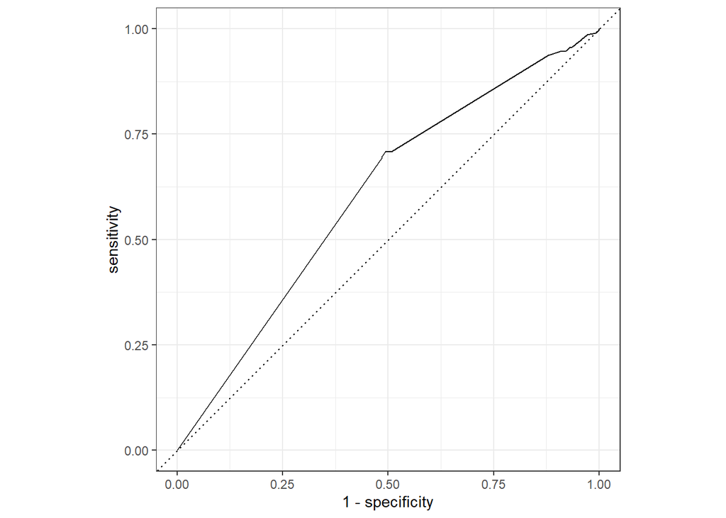

| .metric | .estimator | .estimate |
| --- | --- | --- |
| roc_auc | binary | 0.6062462 |

| term | estimate | penalty |
| --- | --- | --- |
| (Intercept) | -3.50273887 | 0.001 |
| verification_statusVerified | 0.18447468 | 0.001 |
| sub_gradeA2 | -1.04541370 | 0.001 |
| sub_gradeA3 | -0.21322818 | 0.001 |
| sub_gradeA4 | -1.71438445 | 0.001 |
| sub_gradeA5 | -0.36268615 | 0.001 |
| sub_gradeB1 | -0.27368141 | 0.001 |
| sub_gradeB2 | -0.67381233 | 0.001 |
| sub_gradeB3 | -0.27014185 | 0.001 |
| sub_gradeB5 | 0.23981013 | 0.001 |

[output cut: 24 more lines]

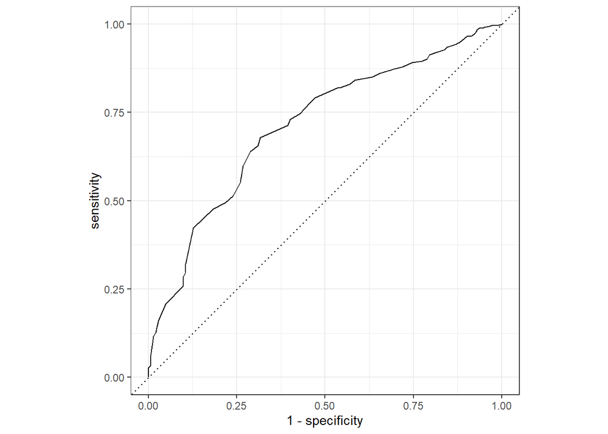

| .metric | .estimator | .estimate |
| --- | --- | --- |
| roc_auc | binary | 0.7122271 |